# O impacto da COVID-19 no meu peso

2021-02-26T19:22:00-03:00

26 de fevereiro de 2020. [Segundo a Wikipedia, essa é a data do início da pandemia de COVID-19 no Brasil](https://pt.wikipedia.org/wiki/Pandemia_de_COVID-19_no_Brasil), com a confirmação de que um homem de 61 anos, morador de São Paulo, que retornou da Itália.

(**trivia:** dois meses antes disso eu estava na Itália. [aqui tem um heatmap mostrando por onde passei](https://marcusnunes.me/posts/heatmap-de-localizacao-no-google/))

Baseado no post que escrevi um ano e meio atrás, intitulado [1000 Dias Com Ela: A Dieta](https://marcusnunes.me/posts/1000-dias-com-ela-a-dieta/), resolvi analisar como meu peso se comportou nesses últimos 366 dias. E esse foi o resultado:

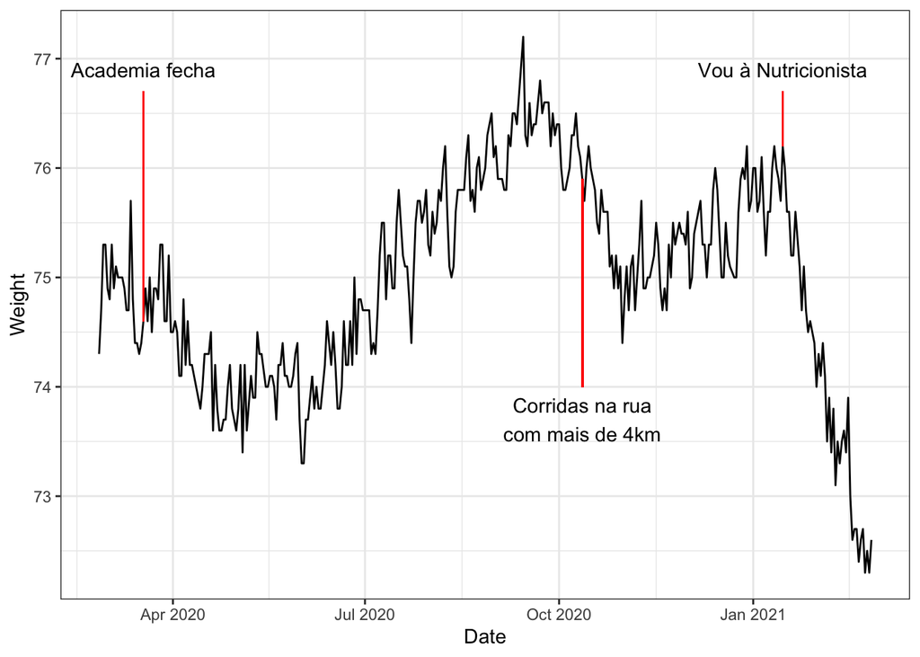

Há três datas em destaque no gráfico acima. Abaixo eu explico o significado delas:

- 18 de Março de 2020: a academia que eu frequentava fechou. A partir desse dia eu fiquei completamente sedentário. Passava os dias sem sair de casa. O gráfico mostra que claramente perdi peso, possivelmente devido à minha perda de massa muscular.
- 12 de Outubro de 2020: depois de tentar largar o sedentarismo, finalmente consegui voltar a ter preparo físico suficiente para correr por mais de 4km na rua. Passei a levantar às 5:15 da manhã para evitar encontrar muitas pessoas. Um pouco antes dessa data eu completei o programa [C25K](http://www.c25k.com/), que me levou do sofá a completar 5km de corrida sem parar.
- 15 de Janeiro de 2021: só passei a ter mais consistência em meu emagrecimento a partir da ida à minha nutricionista. Estou fazendo uma dieta com baixa ingestão de carboidratos e o resultado tem sido bastante bom: 3.5kg a menos em 6 semanas (ou 42 dias).

Os códigos e dados usados nesse post podem ser encontrados no [github](https://github.com/mnunes/MyFitnessPal) (me segue lá).